# Amazon Forest Analysis

## Introduction

##### The Amazon Rainforest is an awe-inspiring natural wonder that covers approximately 5.5 million square kilometers, making it the largest tropical rainforest in the world.

##### It is Situated predominantly in the Amazon Basin. The rainforest extends across Brazil, where the largest portion lies, and extends into neighboring countries in South America. Its geographic expanse is immense, reaching from the Atlantic Ocean in the east to the Andes Mountains in the west.

##### The Amazon's ecological importance cannot be overstated. Its complex web of life, from the towering canopy down to the forest floor, is a critical component of the Earth's biosphere. It helps maintain global climate stability, supports a wide range of ecological interactions, and sustains a vast array of species.

#### My Objectives are to get the answers to the questions:

##### Find the total number of fires that were reported in 2015 and visualize based on each month

##### Average number of fires reported from highest to lowest(state-wise) and visualize

##### Find the states where fires were reported in Dec month.

## Import Libraries

```python
import numpy as np
import pandas as pd
import matplotlib.pyplot as plt
import seaborn as sns
```

```python
df = pd.read_csv(r"C:\Users\Inioluwa Akintunlaji\Downloads\amazon.csv", encoding='latin1')
df
```

|  | year | state | month | number | date |
| --- | --- | --- | --- | --- | --- |
| 0 | 1998 | Acre | Janeiro | 0.0 | 1998-01-01 |
| 1 | 1999 | Acre | Janeiro | 0.0 | 1999-01-01 |
| 2 | 2000 | Acre | Janeiro | 0.0 | 2000-01-01 |
| 3 | 2001 | Acre | Janeiro | 0.0 | 2001-01-01 |
| 4 | 2002 | Acre | Janeiro | 0.0 | 2002-01-01 |
| ... | ... | ... | ... | ... | ... |
| 6449 | 2012 | Tocantins | Dezembro | 128.0 | 2012-01-01 |
| 6450 | 2013 | Tocantins | Dezembro | 85.0 | 2013-01-01 |
| 6451 | 2014 | Tocantins | Dezembro | 223.0 | 2014-01-01 |
| 6452 | 2015 | Tocantins | Dezembro | 373.0 | 2015-01-01 |
| 6453 | 2016 | Tocantins | Dezembro | 119.0 | 2016-01-01 |

6454 rows × 5 columns

## Rename month names from Portuguese to English

```python
# Create a dictionary to map Portuguese month names to English
month_mapping = {
    'Janeiro': 'January','Fevereiro': 'February','Março':'March','Abril':'April', 'Maio':'May', 'Junho':'June', 'Julho':'July',
    'Agosto':'August', 'Setembro':'September', 'Outubro':'October', 'Novembro':'November', 'Dezembro':'December'}

df = pd.read_csv(r"C:\Users\Inioluwa Akintunlaji\Downloads\amazon.csv", encoding='latin1')

# Apply the mapping to the 'month' column
df['month'] = df['month'].map(month_mapping)
df
```

|  | year | state | month | number | date |
| --- | --- | --- | --- | --- | --- |
| 0 | 1998 | Acre | January | 0.0 | 1998-01-01 |
| 1 | 1999 | Acre | January | 0.0 | 1999-01-01 |
| 2 | 2000 | Acre | January | 0.0 | 2000-01-01 |
| 3 | 2001 | Acre | January | 0.0 | 2001-01-01 |
| 4 | 2002 | Acre | January | 0.0 | 2002-01-01 |
| ... | ... | ... | ... | ... | ... |
| 6449 | 2012 | Tocantins | December | 128.0 | 2012-01-01 |
| 6450 | 2013 | Tocantins | December | 85.0 | 2013-01-01 |
| 6451 | 2014 | Tocantins | December | 223.0 | 2014-01-01 |
| 6452 | 2015 | Tocantins | December | 373.0 | 2015-01-01 |
| 6453 | 2016 | Tocantins | December | 119.0 | 2016-01-01 |

6454 rows × 5 columns

## Information about the given data

```python
df.info()
```

```
<class 'pandas.core.frame.DataFrame'>
RangeIndex: 6454 entries, 0 to 6453
Data columns (total 5 columns):
 #   Column  Non-Null Count  Dtype
---  ------  --------------  -----
 0   year    6454 non-null   int64
 1   state   6454 non-null   object
 2   month   6454 non-null   object
 3   number  6454 non-null   float64
 4   date    6454 non-null   object
dtypes: float64(1), int64(1), object(3)
memory usage: 252.2+ KB
```

```python
df.describe()
```

|  | year | number |
| --- | --- | --- |
| count | 6454.000000 | 6454.000000 |
| mean | 2007.461729 | 108.293163 |
| std | 5.746654 | 190.812242 |
| min | 1998.000000 | 0.000000 |
| 25% | 2002.000000 | 3.000000 |
| 50% | 2007.000000 | 24.000000 |
| 75% | 2012.000000 | 113.000000 |
| max | 2017.000000 | 998.000000 |

```python
df.columns
```

```
Index(['year', 'state', 'month', 'number', 'date'], dtype='object')
```

```python
df["year"].info()
```

```
<class 'pandas.core.series.Series'>
RangeIndex: 6454 entries, 0 to 6453
Series name: year
Non-Null Count  Dtype
--------------  -----
6454 non-null   int64
dtypes: int64(1)
memory usage: 50.6 KB
```

## Which month maximum number of forest fires were reported.

```python
max_month = df[df['number'] == df['number'].max()]['month'].values[0]
print(f'Month with the maximum number of forest fires: {max_month}')
```

```
Month with the maximum number of forest fires: September
```

```python
# Find the row with the maximum number of forest fires
max_forest_fires_row = df.loc[df['number'].idxmax()]

# Extract the relevant information
max_forest_fires = max_forest_fires_row['number']
year = max_forest_fires_row['year']
month = max_forest_fires_row['month']
state = max_forest_fires_row['state']


print(f"Maximum number of forest fires: {max_forest_fires} in {month} {year} in {state}")
```

```
Maximum number of forest fires: 998.0 in September 2008 in Amazonas
```

## Which Year maximum number of forest fires were reported

```python
max_year = df[df['number'] == df['number'].max()]['year'].values[0]
print(f'Year with the maximum number of forest fires: {max_year}')
```

```
Year with the maximum number of forest fires: 2008
```

## Find the state with the maximum number of forest fires

```python
max_state = df[df['number'] == df['number'].max()]['state'].values[0]
print(f'State with the maximum number of forest fires: {max_state}')
```

```
State with the maximum number of forest fires: Amazonas
```

## Find the total number of fires reported in Amazonas

```python
amazonas_fires = df[df['state'] == 'Amazonas']['number'].sum()
print(f'Total number of fires reported in Amazonas: {amazonas_fires}')
```

```
Total number of fires reported in Amazonas: 30650.129
```

```python
amazonas_fires = int(df[df['state'] == 'Amazonas']['number'].sum())
print(f'Total number of fires reported in Amazonas: {amazonas_fires}')
```

```
Total number of fires reported in Amazonas: 30650
```

## Display number of fires reported in Amazonas (year-wise) and visualize

```python
amazonas_data = df[df['state'] == 'Amazonas']
amazonas_yearly_fires = amazonas_data.groupby('year')['number'].sum()

print(amazonas_yearly_fires)
```

```
year
1998     946.000
1999    1061.000
2000     853.000
2001    1297.000
2002    2852.000
2003    1524.268
2004    2298.207
2005    1657.128
2006     997.640
2007     589.601
2008    2717.000
2009    1320.601
2010    2324.508
2011    1652.538
2012    1110.641
2013     905.217
2014    2385.909
2015    1189.994
2016    2060.972
2017     906.905
Name: number, dtype: float64
```

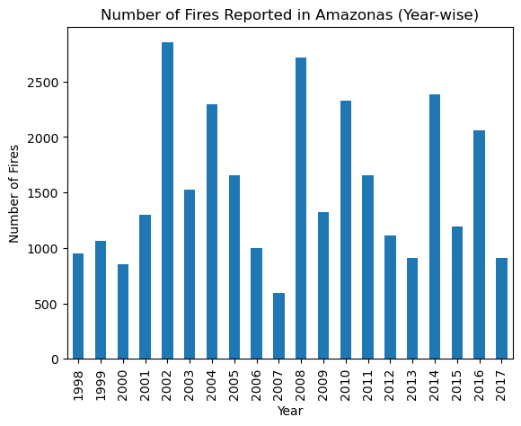

```python
amazonas_yearly_fires = df[df['state'] == 'Amazonas'].groupby('year')['number'].sum()
amazonas_yearly_fires.plot(kind='bar')
plt.xlabel('Year')
plt.ylabel('Number of Fires')
plt.title('Number of Fires Reported in Amazonas (Year-wise)')
plt.show()
```

## Find the total number of fires reported in 2015 and visualize based on each month

```python
# Filter the DataFrame to get data for the year 2015
fires_2015_data = df[df['year'] == 2015]

# Calculate the total number of fires reported in 2015
total_fires_2015 = int(fires_2015_data['number'].sum())

print(f'Total number of fires reported in 2015: {total_fires_2015}')
```

```
Total number of fires reported in 2015: 41208
```

```python
fires_2015_data = df[df['year'] == 2015]

fires_2015_monthly = fires_2015_data.groupby('month')['number'].sum()

print(fires_2015_monthly)
```

```
month
April        2573.000
August       4363.125
December     4088.522
February     2309.000
January      4635.000
July         4364.392
June         3260.552
March        2202.000
May          2384.000
November     4034.518
October      4499.525
September    2494.658
Name: number, dtype: float64
```

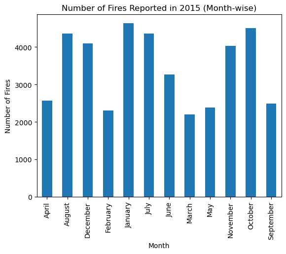

```python
fires_2015 = df[df['year'] == 2015].groupby('month')['number'].sum()
fires_2015.plot(kind='bar')
plt.xlabel('Month')
plt.ylabel('Number of Fires')
plt.title('Number of Fires Reported in 2015 (Month-wise)')
plt.show()
```

## Average number of fires reported from highest to lowest (state-wise) and visualize

```python
average_fires_by_state = df.groupby('state')['number'].mean()

# Sort the states by average number of fires in descending order
average_fires_by_state = average_fires_by_state.sort_values(ascending=False)

print(average_fires_by_state)
```

```
state
Sao Paulo           213.896226
Mato Grosso         201.351523
Bahia               187.222703
Piau                158.174674
Goias               157.721841
Minas Gerais        156.800243
Tocantins           141.037176
Amazonas            128.243218
Ceara               127.314071
Paraiba             109.698573
Maranhao            105.142808
Pará                102.561272
Pernambuco          102.502092
Roraima             102.029598
Santa Catarina      101.924067
Amapa                91.345506
Rondonia             84.876272
Acre                 77.255356
Rio                  62.985865
Espirito Santo       27.389121
Alagoas              19.350000
Distrito Federal     14.899582
Sergipe              13.543933
Name: number, dtype: float64
```

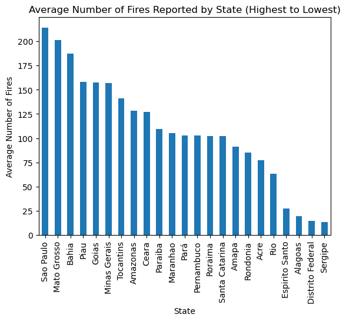

```python
average_fires_by_state = df.groupby('state')['number'].mean().sort_values(ascending=False)
average_fires_by_state.plot(kind='bar')
plt.xlabel('State')
plt.ylabel('Average Number of Fires')
plt.title('Average Number of Fires Reported by State (Highest to Lowest)')
plt.show()
```

## Find the states where fires were reported in Dec month

```python
december_states = df[df['month'] == 'December']['state'].unique()
print(f'States where fires were reported in December: {", ".join(december_states)}')
```

```
States where fires were reported in December: Acre, Alagoas, Amapa, Amazonas, Bahia, Ceara, Distrito Federal, Espirito Santo, Goias, Maranhao, Mato Grosso, Minas Gerais, Pará, Paraiba, Pernambuco, Piau, Rio, Rondonia, Roraima, Santa Catarina, Sao Paulo, Sergipe, Tocantins
```

### CONCLUSION

#### Amazonas Analysis:

##### From the analysis I did on the State nameed Amazonas, I found that a total of approximately 30650 forest fires were reported in Amazonas. I also found the total number of Forest Fires for each year in Amazonas and also Visualized the result.

#### Fires in 2015:

##### In the year 2015, a total of 41208 forest fires were reported after adding up the total of the forest fires of all the states in that year.

#### State-wise Averages:

##### I calculated and visualized the average number of fires reported by state. Sao Paulo with the value 213.896226 approximately 214 had the highest average, while Sergipe with the value 13.543933 approximately 14 had the lowest.

#### Fires in December:

##### I identified states where forest fires were reported in December.

##### This analysis serves as a valuable resource for policymakers, environmental agencies, and local authorities to develop effective strategies for forest fire prevention and management. Understanding the temporal and spatial dynamics of forest fires is essential for preserving natural ecosystems and mitigating the environmental and ecological impacts of fires. Further research and collaboration are recommended to enhance fire prevention and emergency response efforts, ultimately contributing to the conservation of our environment and natural resources.